# CMPT 459.1-19. Programming Assignment 2

FIFA 19 Players

Jingzhe Zhou- 301278504

### Introduction

The data has detailed attributes for every player registered in the latest edition of FIFA 19 database, obtained scraping the website “sofifa.com”. Each instance is a different player, and the attributes give basic information about the players and their football skills. Basic pre-processing was done and Goal Keepers were removed for this assignment.

Please look here for the original data overview and attributes’ descriptions:

- https://www.kaggle.com/karangadiya/fifa19

And here to get a better view of the information:

- https://sofifa.com/

### Reading the data

Assume you want to decide whether to put each player on Defense or not, based on individual metrics. Attributes that make sense for such task were selected and data was already split into train and test datasets. Train was balanced for training purposes. Please see that test dataset is not balanced (keeps original balance).

```r
train <- read.csv('fifa-train.csv')
test <- read.csv('fifa-test.csv')
table(train$Defense)
```

```
##
##   No  Yes
## 4483 4485
```

```r
table(test$Defense)
```

```
##
##   No  Yes
##  675 1121
```

### Decision Trees

“caret” is a R package that encapsulates several methods from other packages. Below we’ll use “rpart” to build a Decision Tree on train dataset to classify “Defense” using all other attributes. We’ll see more on trControl later.

```r
library(caret)
set.seed(1)
dt <- train(Defense ~ ., # Formula
            data = train, # Data
            method = "rpart", # Method
            trControl = trainControl(method = "none")) # Control options
```

We can see the resulting model with:

```r
dt$finalModel
```

```
## n= 8968
##
## node), split, n, loss, yval, (yprob)
##       * denotes terminal node
##
## 1) root 8968 4483 Yes (0.4998885 0.5001115) *
```

Basically it’s just the root node classifying everything as “Yes”. Let’s find out what’s going on.

The method below shows what parameters “caret” package chose to optimize “rpart” within the “train” function.

```r
modelLookup("rpart")
```

|  | model | parameter | label | forReg | forClass | probModel |
| --- | --- | --- | --- | --- | --- | --- |
| 1 | rpart | cp | Complexity Parameter | TRUE | TRUE | TRUE |

So, it’s only optimizing the complexity parameter `cp`. “rpart” actually incorporates pruning during the learning phase, so that any split that does not decrease the overall lack of fit by a factor of `cp` is not even attempted.

Now, the result below shows the values used in the parameters optimized by “caret” to build the model:

```r
dt$bestTune
```

| cp |
| --- |
| 0.4800357 |

So we can see it only tried `cp = 0.4800357`.

**[Task 1]** (5 marks): Please answer the following question. Does the finding above about `cp` explains the resulting model obtained? Justify.

- Yes. complexity parametere just indicated the number of split for the decision tree. The ‘cp’ is larger, split size of the tree will be smaller.So ‘cp’ can only explain the size of the decision tree.

To tell caret’s “train” function to try different values of the parameters it chose to optimize, we can create a grid and pass it to the “train” function. Let’s try the following `cp` value: 0.01

```r
dt <- train(Defense ~ .,
               data = train,
               method = "rpart",
               tuneGrid = expand.grid(cp = 0.01), # GRID for parameters 'caret' optimizes
               trControl = trainControl(method = "none"))
```

Here’s the resulting model:

```r
dt$finalModel
```

```
## n= 8968
##
## node), split, n, loss, yval, (yprob)
##       * denotes terminal node
##
##  1) root 8968 4483 Yes (0.4998885 0.5001115)
##    2) SlidingTackle< 35.5 5152 1500 No (0.7088509 0.2911491)
##      4) HeadingAccuracy>=48.5 3808  744 No (0.8046218 0.1953782) *
##      5) HeadingAccuracy< 48.5 1344  588 Yes (0.4375000 0.5625000)
##       10) LongPassing< 42.5 269   60 No (0.7769517 0.2230483) *
##       11) LongPassing>=42.5 1075  379 Yes (0.3525581 0.6474419) *
##    3) SlidingTackle>=35.5 3816  831 Yes (0.2177673 0.7822327)
##      6) LongPassing< 55.5 804  330 Yes (0.4104478 0.5895522)
##       12) HeadingAccuracy>=50.5 347  122 No (0.6484150 0.3515850) *
##       13) HeadingAccuracy< 50.5 457  105 Yes (0.2297593 0.7702407) *
##      7) LongPassing>=55.5 3012  501 Yes (0.1663347 0.8336653) *
```

Now, let’s plot the tree:

```r
library(rattle)
```

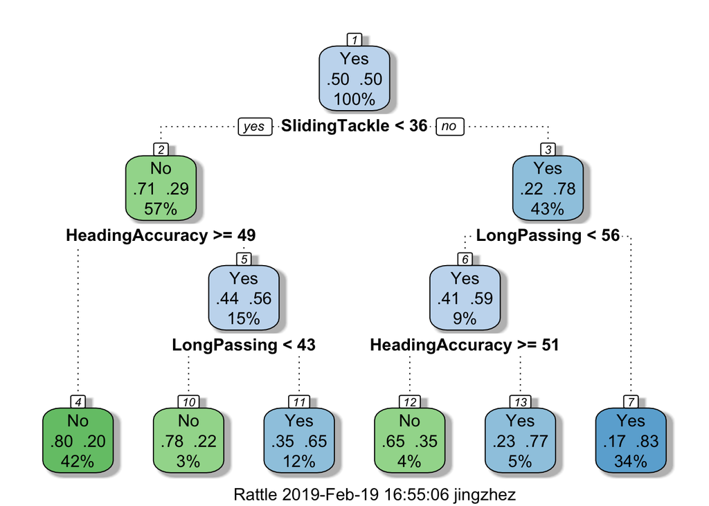

```r
fancyRpartPlot(dt$finalModel)
```

And finally get the confusion matrix on the train dataset:

```r
confusionMatrix(predict(dt), train$Defense, positive = 'Yes')
```

```
## Confusion Matrix and Statistics
##
##           Reference
## Prediction   No  Yes
##        No  3498  926
##        Yes  985 3559
##
##                Accuracy : 0.7869
##                  95% CI : (0.7783, 0.7953)
##     No Information Rate : 0.5001
##     P-Value [Acc > NIR] : <2e-16
##
##                   Kappa : 0.5738
##  Mcnemar's Test P-Value : 0.1846
##
##             Sensitivity : 0.7935
##             Specificity : 0.7803
##          Pos Pred Value : 0.7832
##          Neg Pred Value : 0.7907
##              Prevalence : 0.5001
##          Detection Rate : 0.3969
##    Detection Prevalence : 0.5067
##       Balanced Accuracy : 0.7869
##
##        'Positive' Class : Yes
##
```

**[Task 2]** (1 mark): Please answer the following question. What’s the training accuracy for the model?

- 0.7869

We can also change parameters that “caret” did not choose to optimize but the original function (“rpart” in this case) uses. To do that, we just pass the parameters directly to caret’s “train” function and it will go to “rpart”.

So if we do `?rpart` we’ll see it uses the “parms” argument, where we can change the quality measure for splitting. Its default is “gini” (for Gini Index), so let’s change it and use “information” (for Information Gain).

```r
set.seed(1)
dt <- train(Defense ~ .,
            data = train,
            method = "rpart",
            tuneGrid = expand.grid(cp = 0.01),
            trControl = trainControl(method = "none"),
            parms = list(split = "information") # "gini" is the default
            )
```

Let’s see the confusion matrix for training data:

```r
confusionMatrix(predict(dt), as.factor(train$Defense), positive = 'Yes')
```

```
## Confusion Matrix and Statistics
##
##           Reference
## Prediction   No  Yes
##        No  3462  836
##        Yes 1021 3649
##
##                Accuracy : 0.7929
##                  95% CI : (0.7844, 0.8013)
##     No Information Rate : 0.5001
##     P-Value [Acc > NIR] : < 2.2e-16
##
##                   Kappa : 0.5859
##  Mcnemar's Test P-Value : 1.956e-05
##
##             Sensitivity : 0.8136
##             Specificity : 0.7723
##          Pos Pred Value : 0.7814
##          Neg Pred Value : 0.8055
##              Prevalence : 0.5001
##          Detection Rate : 0.4069
##    Detection Prevalence : 0.5207
##       Balanced Accuracy : 0.7929
##
##        'Positive' Class : Yes
##
```

And plot the tree:

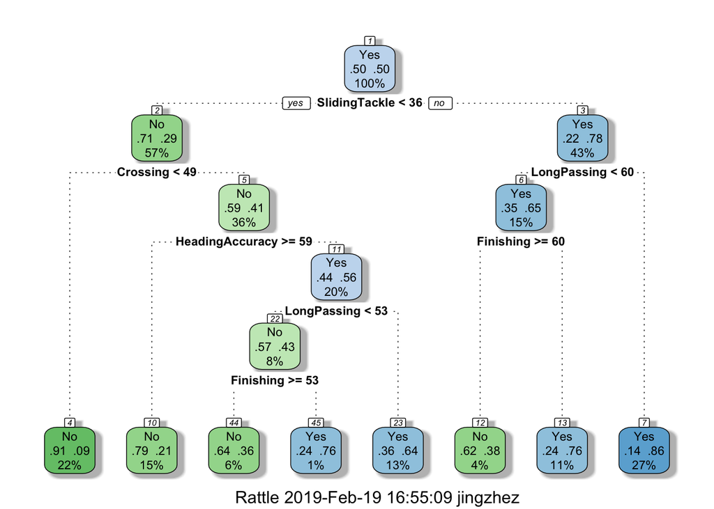

```r
fancyRpartPlot(dt$finalModel)
```

**[Task 3]** (10 marks): Please answer the following questions:

- What’s the training accuracy for the model now? Is it better or worse than before?
- 0.7929. Better
- Is the tree more or less complex overall?
- Yes.The tree size is larger and more complex compared to the gini index one
- Explain possible reasons for the difference observed in complexity observerd in the trees.
- The difference is Task 2 applied gini index, and Task 3 is applied information gain, the way to calculate the weight value is different. And information will have more impurity when comparing to gini.

So far we’ve used a fixed `cp`. Since “caret” chose `cp` to optimize, we can try several values at once. “caret” will then use some resampling method to get the `cp` with best results.

For example, let’s try `cp` values of 0.60, 0.40, 0.10, 0.05, 0.01 on the `tuneGrid` and use Accuracy from **10-fold Cross Validation** to choose the best one. To add such option we change the `trControl` on “train” function.

```r
set.seed(1)
dt <- train(Defense ~ .,
            data = train,
            method = "rpart",
            tuneGrid = expand.grid(cp = c(0.60, 0.40, 0.10, 0.05, 0.01)),
            parms = list(split = "gini"),
            trControl = trainControl(method = "cv", number = 10) # Add Cross-Validation, 10 folds
            )
```

Let’s see the modeling results:

```r
dt
```

```
## CART
##
## 8968 samples
##   36 predictor
##    2 classes: 'No', 'Yes'
##
## No pre-processing
## Resampling: Cross-Validated (10 fold)
## Summary of sample sizes: 8070, 8071, 8072, 8070, 8071, 8071, ...
## Resampling results across tuning parameters:
##
##   cp    Accuracy   Kappa
##   0.01  0.7827855  0.5655624
##   0.05  0.7395188  0.4790486
##   0.10  0.7395188  0.4790486
##   0.40  0.7395188  0.4790486
##   0.60  0.5001115  0.0000000
##
## Accuracy was used to select the optimal model using the largest value.
## The final value used for the model was cp = 0.01.
```

It shows the `cp` chosen as the best (`0.01`), and looking at the accuracy (from 10-fold cross validation) for that `cp` we can see it is `0.7827855`.

We can plot the results for each `cp` tested:

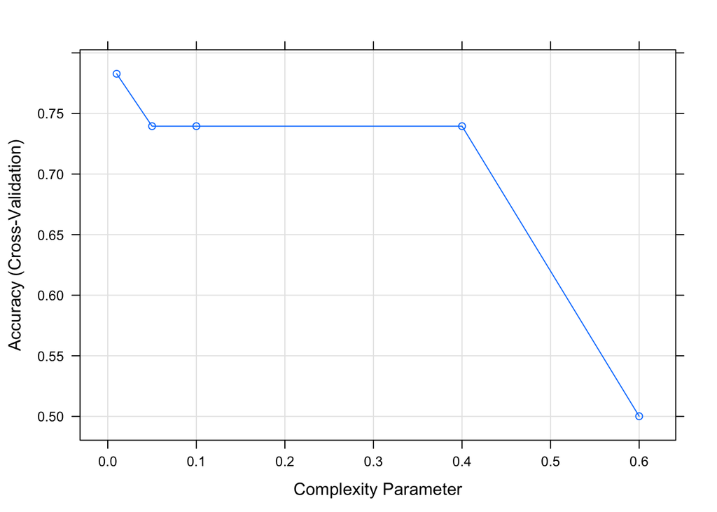

```r
plot(dt)
```

And see the tree:

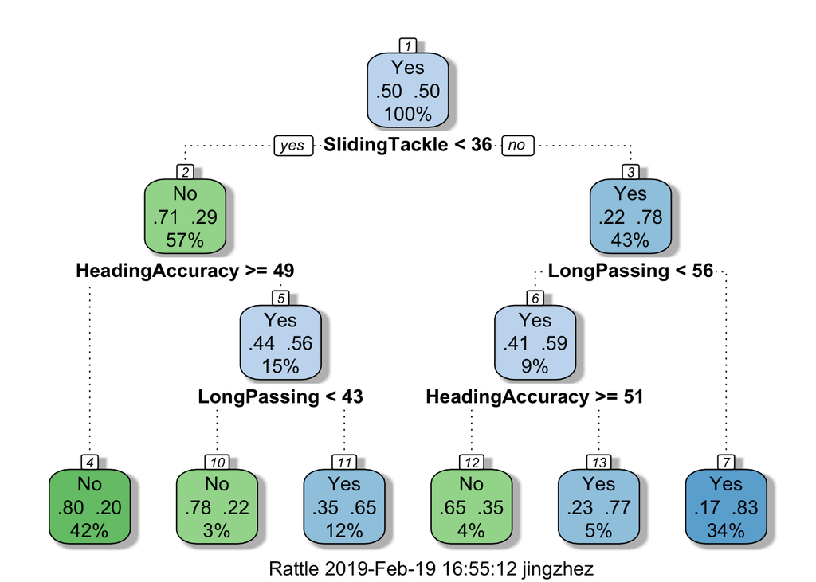

```r
fancyRpartPlot(dt$finalModel)
```

**[Task 4]** (5 marks): Please answer the following questions.

- Comparing training accuracy with 10-fold CV, does the model seem to be overfitting?
- No.
- Does it make sense to be smaller? Justify.
- yes. Because CV will take the average of 10 different training accurracy based on the different training data, but in task 3 it only calculate the 1 of the 10 trianing accuracy with the same cp value. so it will be smaller.

**[Task 5]** (8 marks): Now using the “train” function, test changing values of `cp` (optimized by “caret”" directly) and other parameters from “rpart” (see `?rpart` for help). Try to get the best model you can, considering the 10-Fold CV Accuracy.

```r
set.seed(1)
dt <- train(
            Defense ~ .,
            data = train,
            method = "rpart",
            tuneGrid = expand.grid(cp = c(0.50, 0.20, 0.10, 0.05, 0.0007)),
            parms = list(split = "information"),
            trControl = trainControl(method = "cv", number = 10) # AddCross-Validation, 10 folds

)
```

Show the results for your modeling:

```r
dt
```

```
## CART
##
## 8968 samples
##   36 predictor
##    2 classes: 'No', 'Yes'
##
## No pre-processing
## Resampling: Cross-Validated (10 fold)
## Summary of sample sizes: 8070, 8071, 8072, 8070, 8071, 8071, ...
## Resampling results across tuning parameters:
##
##   cp     Accuracy   Kappa
##   7e-04  0.8146720  0.6293489
##   5e-02  0.7400758  0.4801643
##   1e-01  0.7400758  0.4801643
##   2e-01  0.7400758  0.4801643
##   5e-01  0.5001115  0.0000000
##
## Accuracy was used to select the optimal model using the largest value.
## The final value used for the model was cp = 7e-04.
```

Plot the results for each `cp` tested:

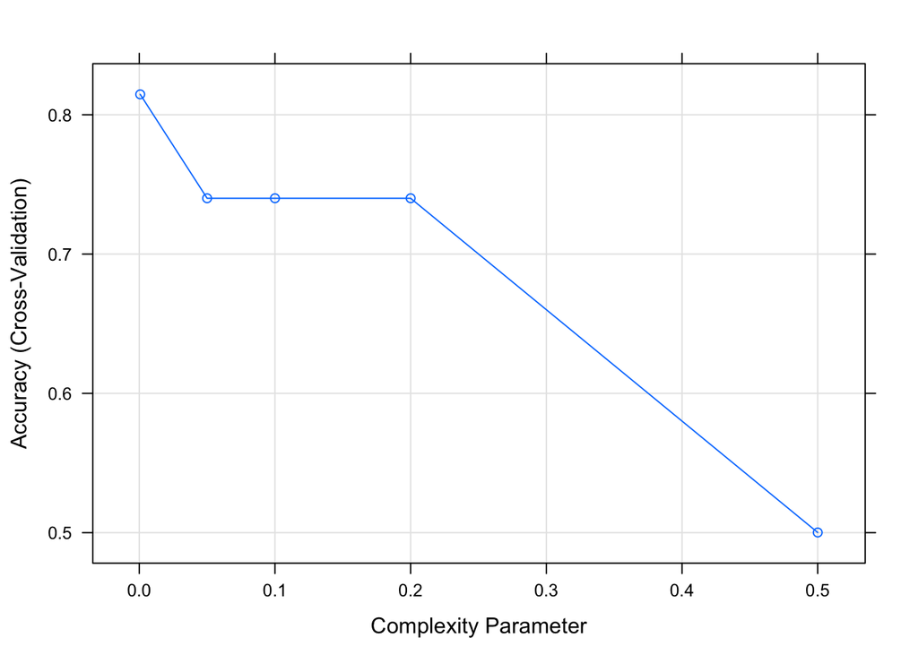

```r
plot(dt)
```

### Logistic Regression

**[Task 6]** (5 marks): Create a logistic regression model using caret’s “train” function with the method “glm” and 10-fold cross validation. Please save the caret’s “train” results on an object “lgr”.

```r
set.seed(1)
lgr <- train(
           Defense ~ .,
           data = train,
           method = "glm",
           trControl = trainControl(method = "cv", number = 10) # AddCross-Validation, 10 folds
)
```

Show the results for your modeling:

```r
lgr
```

```
## Generalized Linear Model
##
## 8968 samples
##   36 predictor
##    2 classes: 'No', 'Yes'
##
## No pre-processing
## Resampling: Cross-Validated (10 fold)
## Summary of sample sizes: 8070, 8071, 8072, 8070, 8071, 8071, ...
## Resampling results:
##
##   Accuracy   Kappa
##   0.8123339  0.6246645
```

Let’s see the coefficients of the logistic regression model.

```r
summary(lgr$finalModel)
```

```
##
## Call:
## NULL
##
## Deviance Residuals:
##     Min       1Q   Median       3Q      Max
## -2.6488  -0.5976   0.0870   0.6345   3.5518
##
## Coefficients:
##                       Estimate Std. Error z value Pr(>|z|)
## (Intercept)         -3.593e+00  1.589e+00  -2.262 0.023717 *
## Age                  1.131e-02  9.126e-03   1.240 0.215078
## Value               -1.607e-08  9.045e-09  -1.776 0.075658 .
## Wage                -1.392e-05  2.488e-06  -5.594 2.21e-08 ***
## Height               1.609e-02  8.341e-03   1.929 0.053784 .
## Weight              -5.802e-03  3.391e-03  -1.711 0.087073 .
## Crossing            -6.267e-03  4.342e-03  -1.443 0.148902
## Finishing           -3.071e-02  5.865e-03  -5.237 1.63e-07 ***
## HeadingAccuracy     -3.653e-02  3.951e-03  -9.246  < 2e-16 ***
## ShortPassing         3.945e-02  8.609e-03   4.583 4.59e-06 ***
## Volleys              2.758e-03  4.529e-03   0.609 0.542636
## Dribbling           -6.165e-04  8.888e-03  -0.069 0.944701
## Curve               -1.424e-02  4.375e-03  -3.255 0.001133 **
## FKAccuracy           1.282e-02  3.545e-03   3.615 0.000300 ***
## LongPassing          6.933e-02  5.649e-03  12.273  < 2e-16 ***
## BallControl         -6.897e-03  1.010e-02  -0.683 0.494605
## Acceleration        -1.938e-04  6.638e-03  -0.029 0.976705
## SprintSpeed         -1.133e-02  6.161e-03  -1.838 0.066035 .
## Agility              5.272e-03  4.905e-03   1.075 0.282439
## Reactions           -2.060e-02  6.045e-03  -3.407 0.000657 ***
## Balance              8.966e-03  4.781e-03   1.875 0.060752 .
## ShotPower            8.465e-03  5.596e-03   1.513 0.130373
## Jumping             -1.434e-03  2.871e-03  -0.499 0.617488
## Stamina              2.222e-03  3.431e-03   0.648 0.517087
## Strength            -1.057e-02  4.097e-03  -2.581 0.009865 **
## LongShots            7.818e-04  5.243e-03   0.149 0.881458
## Aggression           2.027e-03  2.785e-03   0.728 0.466682
## Positioning         -2.225e-02  6.410e-03  -3.471 0.000519 ***
## Vision               4.834e-02  6.003e-03   8.053 8.09e-16 ***
## Penalties           -1.131e-02  4.214e-03  -2.684 0.007279 **
## Composure           -2.278e-02  5.577e-03  -4.085 4.40e-05 ***
## Marking              1.682e-02  2.866e-03   5.869 4.38e-09 ***
## StandingTackle       1.830e-02  5.337e-03   3.430 0.000603 ***
## SlidingTackle       -8.339e-04  5.400e-03  -0.154 0.877275
## Release.Clause       1.382e-08  5.267e-09   2.624 0.008696 **
## Preferred.FootRight  1.035e-01  6.963e-02   1.486 0.137163
## ---
## Signif. codes:  0 '***' 0.001 '**' 0.01 '*' 0.05 '.' 0.1 ' ' 1
##
## (Dispersion parameter for binomial family taken to be 1)
##
##     Null deviance: 12432.3  on 8967  degrees of freedom
## Residual deviance:  7628.1  on 8932  degrees of freedom
## AIC: 7700.1
##
## Number of Fisher Scoring iterations: 5
```

**[Task 7]** (10 marks): Look at the coefficients above, please answer the following questions: - Based on the coefficients, do you think the model is overfitting? Justify. - No, the coefficient is small, which indicate a polynomial function will be more flat. - Is there anything we can do to improve the model? - normalize the dataset before generating the model

**[Task 8]** (10 marks): Manually pick attributes to *not* use for training. Justify your choices. Pick more/less attributes until the model improves (based on 10-fold CV on train). For that create a new dataset called “train_selec” that is equal to “train” dataset without the selected attributes.

```r
# Create "train_selec"
remove_col = c("Jumping","Value","Age","Preferred.Foot")
train_selec <- train[, !(names(train) %in% remove_col)]
```

```r
# Now train Logistic Regression using "train_selec"
set.seed(1)
lgr <- train(
           Defense ~ .,
           data = train_selec,
           method = "glm",
           trControl = trainControl(method = "cv", number = 10) # AddCross-Validation, 10 folds
)
```

Show the results for your modeling:

```r
lgr
```

```
## Generalized Linear Model
##
## 8968 samples
##   32 predictor
##    2 classes: 'No', 'Yes'
##
## No pre-processing
## Resampling: Cross-Validated (10 fold)
## Summary of sample sizes: 8070, 8071, 8072, 8070, 8071, 8071, ...
## Resampling results:
##
##   Accuracy   Kappa
##   0.8134486  0.6268942
```

**[Task 9]** (8 marks): How do you explain the model getting better results with less attributes?

- In my opinion, the attribute I chose will not affect to resulting model, which means the attribute I selected will be the noisy data, and it will affect the accuracy of the result. So It will get a better result

**From now on, please use only `train_selec` to train models.**

### K-Nearest Neighbors

**[Task 10]** (5 marks): Create a K-Nearest Neighbors model using caret’s “train” function with the method “knn” and 10-fold cross validation. Use the function `modelLookup("knn")` to see the available optimization parameters, try at least ten different k values and please save the caret’s “train” results on an object “knn”.

Also remember to now use “train_selec”.

```r
modelLookup("knn")
```

|  | model | parameter | label | forReg | forClass | probModel |
| --- | --- | --- | --- | --- | --- | --- |
| 1 | knn | k | #Neighbors | TRUE | TRUE | TRUE |

```r
set.seed(1)
knn <- train(
            Defense ~ .,
            data = train_selec,
            method = "knn",
            tuneLength = 10,
            trControl = trainControl(method = "cv", number = 10) # AddCross-Validation, 10 folds
)
```

Show the results for your modeling:

```r
knn
```

```
## k-Nearest Neighbors
##
## 8968 samples
##   32 predictor
##    2 classes: 'No', 'Yes'
##
## No pre-processing
## Resampling: Cross-Validated (10 fold)
## Summary of sample sizes: 8070, 8071, 8072, 8070, 8071, 8071, ...
## Resampling results across tuning parameters:
##
##   k   Accuracy   Kappa
##    5  0.6504267  0.3008636
##    7  0.6173091  0.2346275
##    9  0.6219909  0.2439909
##   11  0.6081665  0.2163419
##   13  0.6082771  0.2165650
##   15  0.5989123  0.1978394
##   17  0.5922184  0.1844483
##   19  0.5918836  0.1837807
##   21  0.5803989  0.1608047
##   23  0.5712565  0.1425234
##
## Accuracy was used to select the optimal model using the largest value.
## The final value used for the model was k = 5.
```

Plot the results for each `k` tested:

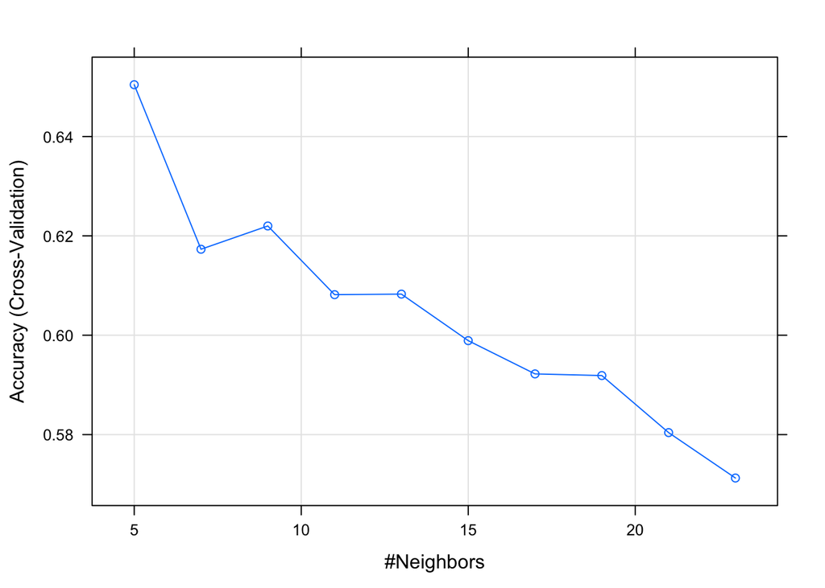

```r
plot(knn)
```

**[Task 11]** (8 marks): Please answer the following question: Why did K-NN get bad results? Explain.

- Because the data is not normailzed before proceed the K-NN, which caused the distance among the points probably is not in the same domination.

**[Task 12]** (3 marks): Now fix the problem with “knn”, using an additional argument of caret’s “train” function. Save the resulting model on “knn”.

```r
set.seed(1)
knn <- train(
            Defense ~ .,
            data = train_selec,
            method = "knn",
            tuneLength = 10,
            trControl = trainControl(method = "cv", number = 10), # AddCross-Validation, 10 folds
            preProcess = c("center","scale")
)
```

Show the results for your modeling:

```r
knn
```

```
## k-Nearest Neighbors
##
## 8968 samples
##   32 predictor
##    2 classes: 'No', 'Yes'
##
## Pre-processing: centered (31), scaled (31)
## Resampling: Cross-Validated (10 fold)
## Summary of sample sizes: 8070, 8071, 8072, 8070, 8071, 8071, ...
## Resampling results across tuning parameters:
##
##   k   Accuracy   Kappa
##    5  0.8142270  0.6284556
##    7  0.8040808  0.6081632
##    9  0.8101002  0.6202005
##   11  0.8098784  0.6197572
##   13  0.8118844  0.6237683
##   15  0.8105478  0.6210935
##   17  0.8103254  0.6206495
##   19  0.8098771  0.6197540
##   21  0.8082045  0.6164077
##   23  0.8065322  0.6130642
##
## Accuracy was used to select the optimal model using the largest value.
## The final value used for the model was k = 5.
```

Plot the results for each `k` tested:

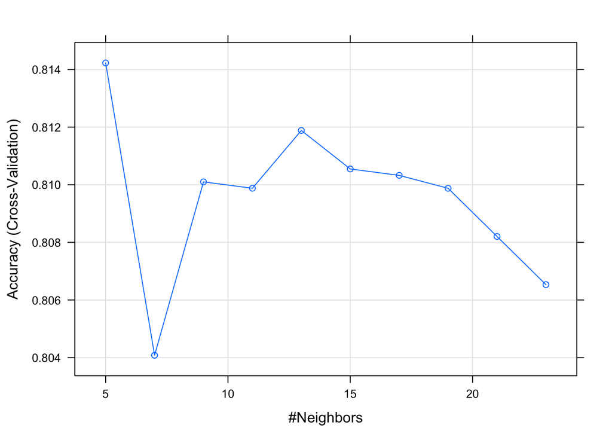

```r
plot(knn)
```

So far we’ve been using “Accuracy” as our main classification metric to get the best model. Let’s change that.

Please run the code below for a new function to be used.

```r
library(MLmetrics)
metrics_summary <- function(data, lev = NULL, model = NULL) {
  data <- as.data.frame(data)
  lvls <- levels(data$obs)
  f1_val <- F1_Score(y_pred = data$pred, y_true = data$obs, positive = lev[2])
  auc_val <- ModelMetrics::auc(ifelse(data$obs == lev[1], 0, 1), data[, lvls[2]])
  acc_val <- Accuracy(y_pred = data$pred, y_true = data$obs)
  prec_val <- Precision(y_pred = data$pred, y_true = data$obs, positive = lev[2])
  rec_val <- Recall(y_pred = data$pred, y_true = data$obs, positive = lev[2])
  c(F1 = f1_val, AUC = auc_val, Accuracy = acc_val, Precision = prec_val, Recall = rec_val)
}
```

**[Task 13]** (3 marks): Please copy and paste your last K-NN model building using caret’s “train”, and then replace your current `trControl` with `trControl = trainControl(method = "cv", number = 10, classProbs = TRUE, summaryFunction = metrics_summary)`. Also add the following new argument to “train” function: `metric = "F1"`. Please save the resulting model as “knn2”.

```r
set.seed(1)
knn2 <- train(
            Defense ~ .,
            data = train_selec,
            method = "knn",
            tuneLength = 10,
            trControl = trainControl(method = "cv", number = 10, classProbs = TRUE, summaryFunction = metrics_summary), # AddCross-Validation, 10 folds
            metric = "F1",
            preProcess = c("center","scale")
)
```

Show the results for your modeling:

```r
knn2
```

```
## k-Nearest Neighbors
##
## 8968 samples
##   32 predictor
##    2 classes: 'No', 'Yes'
##
## Pre-processing: centered (31), scaled (31)
## Resampling: Cross-Validated (10 fold)
## Summary of sample sizes: 8070, 8071, 8072, 8070, 8071, 8071, ...
## Resampling results across tuning parameters:
##
##   k   F1         AUC        Accuracy   Precision  Recall
##    5  0.8116787  0.8843453  0.8142270  0.8234691  0.8004350
##    7  0.8015613  0.8896746  0.8040808  0.8124076  0.7912971
##    9  0.8098324  0.8912284  0.8101002  0.8114225  0.8086850
##   11  0.8101535  0.8931782  0.8098784  0.8092831  0.8113640
##   13  0.8128710  0.8929801  0.8118844  0.8088413  0.8173829
##   15  0.8131709  0.8944639  0.8105478  0.8023498  0.8247450
##   17  0.8128534  0.8949754  0.8103254  0.8025442  0.8238526
##   19  0.8120362  0.8952757  0.8098771  0.8032067  0.8214022
##   21  0.8117940  0.8951571  0.8082045  0.7972187  0.8271973
##   23  0.8096857  0.8952885  0.8065322  0.7970738  0.8229622
##
## F1 was used to select the optimal model using the largest value.
## The final value used for the model was k = 15.
```

Plot the results for each `k` tested:

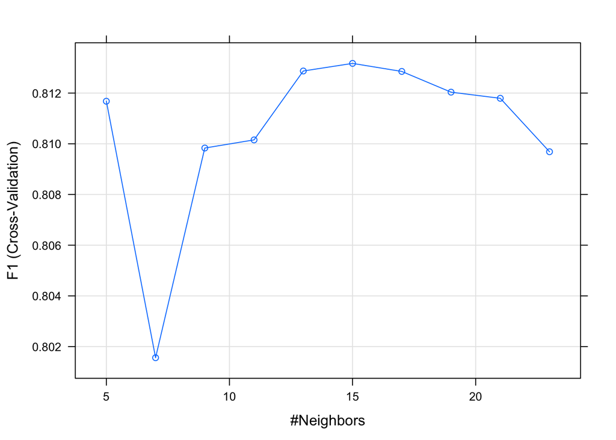

```r
plot(knn2)
```

### Support Vector Machines

**[Task 15]** (10 marks): Create a SVM model using caret’s “train” function. Choose one of the methods from “http://topepo.github.io/caret/train-models-by-tag.html#support-vector-machines”. Perform 10-fold cross validation and try different optimization parameters (`tuneGrid`) to get the best model you can. Please save the caret’s “train” results on object “svm”. **Method suggested: “svmLinear2”.**

Also remember to now use “train_selec”.

```r
set.seed(1)
svm <- train(
            Defense ~ .,
            data = train_selec,
            method = "svmLinear2",
            tuneLength = 10,
            tuneGrid= expand.grid(cost = c(0.50,0.25,0.1)),
            trControl = trainControl(method = "cv", number = 10, classProbs = TRUE, summaryFunction = metrics_summary), # AddCross-Validation, 10 folds
            preProcess = c("center","scale")
)
```

Show the results for your modeling:

```r
svm
```

```
## Support Vector Machines with Linear Kernel
##
## 8968 samples
##   32 predictor
##    2 classes: 'No', 'Yes'
##
## Pre-processing: centered (31), scaled (31)
## Resampling: Cross-Validated (10 fold)
## Summary of sample sizes: 8070, 8071, 8072, 8070, 8071, 8071, ...
## Resampling results across tuning parameters:
##
##   cost  F1         AUC        Accuracy   Precision  Recall
##   0.10  0.8196076  0.8810912  0.8132244  0.7930098  0.8481591
##   0.25  0.8190498  0.8811777  0.8126671  0.7925505  0.8474905
##   0.50  0.8191743  0.8811677  0.8127787  0.7925912  0.8477137
##
## Accuracy was used to select the optimal model using the largest value.
## The final value used for the model was cost = 0.1.
```

Show the final model:

```r
svm$finalModel
```

```
##
## Call:
## svm.default(x = as.matrix(x), y = y, kernel = "linear", cost = param$cost,
##     probability = classProbs)
##
##
## Parameters:
##    SVM-Type:  C-classification
##  SVM-Kernel:  linear
##        cost:  0.1
##       gamma:  0.03225806
##
## Number of Support Vectors:  4081
```

Plot the results for each parameter tested:

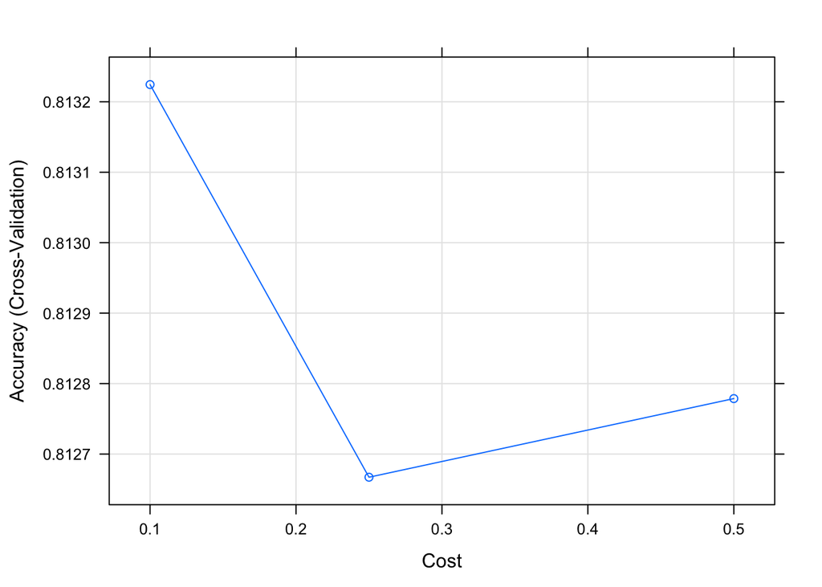

```r
plot(svm)
```

### Choosing the best model

Please run the following code to show 10-fold Cross Validation accuracy for all models:

```r
cv_metrics <- function(model){
  model$results[row.names(model$bestTune), 'Accuracy']
}
sapply(list(dt, lgr, knn, knn2, svm), cv_metrics)
```

```
## [1] 0.8146720 0.8134486 0.8142270 0.8105478 0.8132244
```

**[Task 16]** (1 mark): Which model is the best and what was its 10-fold CV Accuracy?

- Decision Tree

### Evaluating on test dataset

Please run the code below to evaluate the performance of all the best models (of their corresponding type) on the test dataset.

```r
data_metrics <- function(model, thedata){
  res <- predict(model, newdata = thedata, type = "prob")$Yes
  data <- data.frame(pred = ifelse(res >= 0.5, 'Yes', 'No'), obs = as.factor(thedata$Defense), Yes = res)
  lev = c('No', 'Yes')
  metrics_summary(data, lev)
}

sapply(list(dt, lgr, knn, knn2, svm), data_metrics, thedata=test)
```

```
##                [,1]      [,2]      [,3]      [,4]      [,5]
## F1        0.8349337 0.8542805 0.8326493 0.8443439 0.8580470
## AUC       0.8529858 0.8844326 0.8501589 0.8785661 0.8828242
## Accuracy  0.7989978 0.8218263 0.7956570 0.8084633 0.8251670
## Precision 0.8564728 0.8725581 0.8516791 0.8567493 0.8698442
## Recall    0.8144514 0.8367529 0.8144514 0.8322926 0.8465656
```

**[Task 17]** (3 marks): Looking at the test results, please answer the following questions: